```python
try:
    # %tensorflow_version only exists in Colab.
    %tensorflow_version 2.x
    IS_COLAB = True
except Exception:
    IS_COLAB = False

if IS_COLAB:
    !git clone https://github.com/Merijn68/BondTrading.git
    %pip install -q "ray[tune]" bayesian-optimization
    %pip install loguru tensorflow-addons
    %cd BondTrading
```

[output not shown]

# Base model

In eerste instantie gaan we alleen naar het signaal zelf kijken. We nemen dus alleen de prijs mee in de modellering. De verwachting is dat dit model niet erg goed gaat werken. De financiele markt is stochastisch. Of zoals lange tijd door de AFM voorgeschreven: "Resultaten uit het verleden, geven geen garantie voor de toekomst". In de 2e fase van dit onderzoek zullen we features gaan toevoegen. Door eerst te analyseren wat het model doet zonder features kunnen we zien in hoevere we met het toevoegen van features tot een betere voorspelling kunnen komen.

Eerst wordt een naive voorspelling gemaakt voor de bond markt. Het doel hiervan is om een benchmark te hebben waarmee de andere modellen kunnen worden vergeleken. We voorspellen voor 1 bond voor 10 dagen vooruit wat de bond prijs gaat doen. De naive voorspelling is dat de bond prijs van gisteren ook de bond prijs blijft voor de aankomende 10 dagen.

Dit onderzoek richt zich specifiek op neurale netwerken. We onderzoeken 'simpele' Recurrent Neurale Netwerken, en vergelijken dit met moderne architecturen met LSTM en GRU units. Het is ook goed mogelijk om met 'klassieke' methoden een tijdreeksvoorspelling doen. Vanuit de statistiek zijn er veel mogelijkheden beschikbaar om met autoregressie of multiple regressie aan de slag te gaan. Maar juist door het stochatische karakter van de tijdreeks, verwachten we ook hier geen goed werkend model mee te kunnen ontwikkelen. Dit valt verder buiten de scope voor dit onderzoek.

```python
%load_ext autoreload
%autoreload 2

import matplotlib.pyplot as plt
from pathlib import Path

import tensorflow as tf
from sklearn.preprocessing import MinMaxScaler
from tensorflow.keras.callbacks import TensorBoard, EarlyStopping
from tensorflow.keras.optimizers import Adam
from tensorflow.keras.callbacks import ReduceLROnPlateau
from tqdm import tqdm

from src.data import make_dataset, window, split
from src.models import evaluate, hyper
from src.models.base_model import BaseModel, RnnModel
from src.visualization import visualize
```

```python
df_price = make_dataset.read_pkl('price', path = Path("data/processed/"), colab = IS_COLAB )
isin = "NL0011220108" # 10 Years NL Bond, maturity 2025 0.25% coupon

df_isin = df_price[df_price['reference_identifier'] == isin]
df_isin = df_isin.set_index('rate_dt')
df_isin = df_isin.sort_index()
```

```
2022-02-09 10:18:14.481 | INFO     | src.data.make_dataset:read_pkl:376 - Load preprocessed price data
```

Voor dit onderzoek maken we gebruik van een train test split. Voor tijdreeksen is het echter wel belangrijk om de tijdvolgorde te behouden. Voor de test split wordt daarom het einde van de dataset gekozen - en alle voorliggende historie wordt gebruikt voor de trainingdata. De train/test split is gekozen op 70% training data en 30% test data. De split in train / test is zo gekozen dat er voldoende testdata overblijft om de modellen te testen. Er is bewust voor gekozen om geen data achter te houden voor een splitsing in een test en Validatie set. Wanneer het model voldoende succesvol is op de testset kan eenvoudig meer data worden verzameld om het model in de praktijk uit te testen.

```python
df_train, df_test = split.split_data(df_isin, 0.7,['mid'])
```

```
2022-02-09 10:18:42.204 | INFO     | src.data.split:split_data:21 - Train test split data 1731 70.0%,train data 1211, test data 520.
```

Om deze dataset te kunnen verwerken moeten we kijken of de data genormaliseerd of gestandaardizeerd moet worden. Uit onderzoek is gebleken dat wanneer we de data onbewerkt gebruiken het model niet tot een juiste inschatting komt van de marktwaarde. Bij standardizatie of normalizatie sluit de voorspelling veel beter aan op de data. Het is beter om de data niet te standardizeren omdat de data niet normaal verdeeld is. Dit wordt ook zichtbaar in de distributieplot van de prijzen.

```
findfont: Font family ['Arial'] not found. Falling back to DejaVu Sans.
```

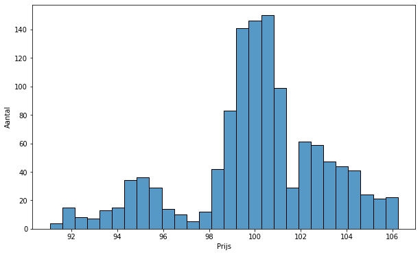

```python
visualize.distribution(
    df_train, x= 'mid',
    figurepath = Path("reports/figures"),
    name = 'Single Bond Distribution'
)
plt.show()
```

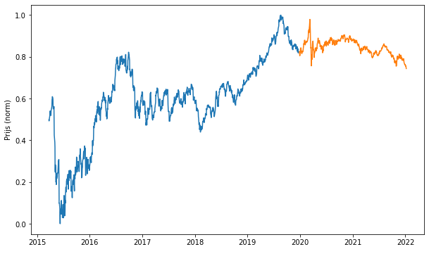

```python
scaler = MinMaxScaler()
df_train[df_train.columns] = scaler.fit_transform(df_train[df_train.columns])
df_test[df_test.columns] = scaler.transform(df_test[df_test.columns])

visualize.timeplot(
    df_train['mid'],
    df_test['mid'],
    x_label = ' ',
    y_label = 'Prijs (norm)',
    figurepath = Path("reports/figures"),
    name = 'timeseries traintestsplit')
plt.show()
```

Van deze dataset wordt een windowed dataset gemaakt, waar de tijdsreeks wordt opgedeeld in batches. De batch size en suffle buffer parameters zijn hyper parameters die worden meegenomen bij het hypertunen van het model. In het algemeen kan verwacht worden dat een grotere batch size - zolang dit nog redelijkerwijs in het geheugen past sneller verwerkt kan worden. Maar batch size heeft ook effect op de data die het model tegelijkertijd te zien krijgt. De resultaten van het model worden dus ook beinvloed door deze instellingen.

```python
# Create a windowed dataset from the data
window_size = 32
batch_size = 64
shuffle_buffer = 4
horizon = 10
train_set = window.windowed_dataset(df_train, window_size, batch_size, shuffle_buffer, horizon=horizon)
valid_set = window.windowed_dataset(df_test, window_size, batch_size, shuffle_buffer, horizon=horizon)
x, y = next(iter(train_set))
x.shape, y.shape
```

```
2022-02-09 10:18:51.138 | INFO     | src.data.window:windowed_dataset:20 - Split windowed dataset window_size = 32 batch_size =  64, shuffle_buffer =  4 ,horizon =  10
2022-02-09 10:18:53.828 | INFO     | src.data.window:windowed_dataset:20 - Split windowed dataset window_size = 32 batch_size =  64, shuffle_buffer =  4 ,horizon =  10
```

```
(TensorShape([64, 32, 1]), TensorShape([64, 10]))
```

# Naive Model

We moeten een metriek kiezen om het model te evalueren. Voor de evaluatie willen we zien dat het model het ten minste zo goed doet als het naive model. We berekenen een ['Scaled' Mean Absolute Error](https://en.wikipedia.org/wiki/Mean_absolute_scaled_error#:~:text=In%20statistics%2C%20the%20mean%20absolute,2005%20by%20statistician%20Rob%20J). als metriek voor het meten van de performance van de modellen.

In eerste instantie worden de modellen getrained op het minimaliseren van de Mean Squared Error. Deze metric zorgt er voor dat outliners extra hard worden afgestraft, waardoor het model sneller convergeert. In Notebook 6 wordt gekeken of we met een custom loss functie nog een betere voorspelling kunnen krijgen.

```python
y, yhat = evaluate.naivepredict(df_train['mid'].values)
norm = evaluate.mae(y, yhat)
print('1 step Mean Absolute Error: ', evaluate.mae(y, yhat))

# Mean Absolute Error - for horizon
norm = evaluate.calc_mae_for_horizon(train_set, horizon)
print(f'Mean Absolute Error for {horizon} timesteps', norm)

# Scaled Mean Absolute Error function
smae = evaluate.ScaledMAE(scale=norm)
```

```
1 step Mean Absolute Error:  0.01223082831764435
Mean Absolute Error for 10 timesteps 0.02729345144816911
```

```python
%load_ext tensorboard
```

```python
result = {}
models = {}
```

Het meest eenvoudige Neurale netwerk we hier kunnen toepassen is alleen een dense layer van het aantal dagen waarvoor we een voorspelling willen maken.

```python
config = {
    'horizon'   : horizon,
    'window'    : window_size
}
name = 'BaseModel'
model = BaseModel(name,config)
early_stop = EarlyStopping(patience=10, restore_best_weights=True)
lr = 1e-2
model.compile(loss="mse", optimizer=Adam(learning_rate=lr), metrics=["mae", smae])
result[name] = model.fit(train_set,epochs=200, validation_data=valid_set, callbacks=[early_stop], verbose=0)
models[name] = model
print(model.evaluate(valid_set))
```

```
[0.0010635815560817719, 0.02337242104113102, 0.8563380837440491]
```

Vervolgens kunnen we een model maken met 1 RNN laag en een Dense output layer voor het aantal dagen waarvoor we de koers willen voorspellen.

```python
config = {
    'horizon'   : horizon,
    'window'    : window_size
}
name = 'BaseRnnModel'
model = RnnModel(name,config)
early_stop = EarlyStopping(patience=10, restore_best_weights=True)
lr = 1e-2
model.compile(loss="mse", optimizer=Adam(learning_rate=lr), metrics=["mae", smae])
result[name] = model.fit(train_set,epochs=200, validation_data=valid_set, callbacks=[early_stop], verbose=0)
models[name] = model
print(model.evaluate(valid_set))
```

```
[0.00044598933891393244, 0.01434266660362482, 0.5254984498023987]
```

Wanneer we voor een aantal voorbeelden kijken naar de voorspelling op basis van de validatie set, geeft dit een goede indruk van de presetaties van het model. Opvallend is dat het model ongeacht de time step ongeveer tot dezelfde voorspelling komt.

```
findfont: Font family ['Arial'] not found. Falling back to DejaVu Sans.
```

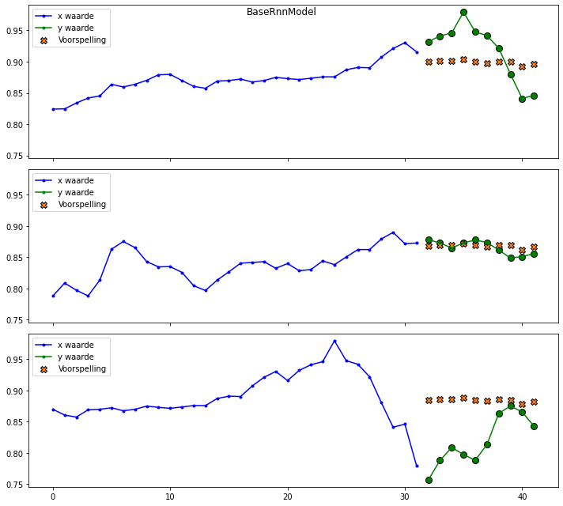

```python
fig = visualize.plot_example(
    valid_set,
    window_size = window_size,
    horizon = horizon,
    examples = 3,
    model = model,
    figurepath = Path("reports/figures"))
```

```python
# Remove log files before tuning models
if IS_COLAB:
  !rm -rf logs/
else:
  !del logs /Q
  !del %USERPROFILE%\AppData\Local\Temp\.tensorboard-info\*.* /Q
```

We onderzoeken het effect van de learning rate op de data. Wanneer de learning rate te hoog staat ingesteld kan het model schokkerig worden, en op een gegeven moment niet dieper komen. wanneer de learning rate te laag is ingesteld, duurt het te lang voor het model om verder te leren. Met het reduced learning rate model verlagen we de learning rate automatisch wanneer het model op een plateau vast komt te zitten en niet dieper leert.

```python
for lr in [1e-2, 1e-3, 1e-4]:
    name = f"simpleRNN_Adam{lr}"
    logdir = Path("logs") / name
    tb = TensorBoard(logdir, histogram_freq=1)
    model.compile(loss="mse", optimizer=Adam(learning_rate=lr), metrics=["mae", smae])
    result[name] = model.fit(train_set,epochs=200, validation_data=valid_set, callbacks=[early_stop, tb], verbose=0)
    models[name] = model
    print('lr:', lr, model.evaluate(valid_set))
```

```
lr: 0.01 [0.0004914693417958915, 0.015335582196712494, 0.5618776679039001]
lr: 0.001 [0.00043266924330964684, 0.013390797190368176, 0.49062302708625793]
lr: 0.0001 [0.0004329107468947768, 0.013396194204688072, 0.49082082509994507]
```

```python
name = f"simpleRNN_Adam_rlr"
logdir = Path("logs") / name
tb = TensorBoard(logdir, histogram_freq=1)
lr = 0.01
reduce_lr = ReduceLROnPlateau(monitor='smae', factor=0.8,
                              patience=5, min_lr=1e-5)
model.compile(loss="mse", optimizer=Adam(learning_rate = lr), metrics=["mae", smae])
result[name] = model.fit(train_set, epochs=200, validation_data=valid_set, callbacks=[reduce_lr, early_stop, tb], verbose=0)
models[name] = model

print(name + ":", model.evaluate(valid_set))
```

```
simpleRNN_Adam_rlr: [0.00043248225119896233, 0.013147132471203804, 0.4816954731941223]
```

```python
%tensorboard --logdir logs
```

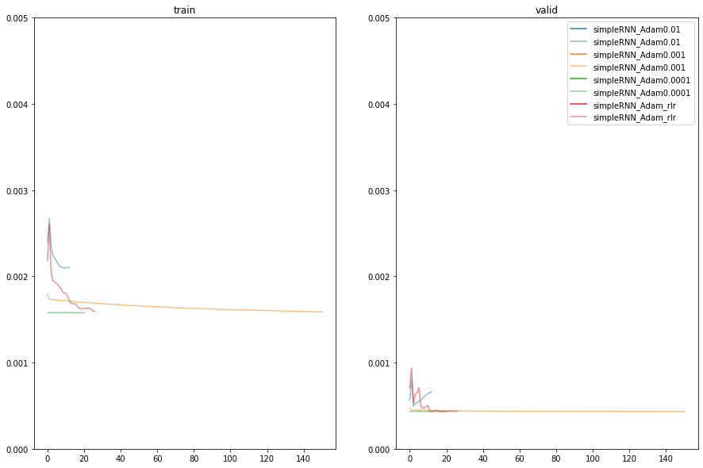

```python
from src.models import evaluate
visualize.plot_results(result, ymax = 0.005, subset="simple")
```

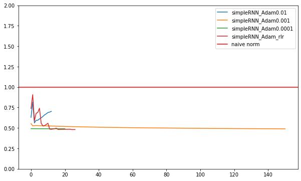

```python
plt.figsize=(8,12)
visualize.naive(result, ylim=2.0, subset="simple")
```

### Uitbreiden van het model

We gaan nu het model voorzichtig uitbreiden. We verhogen het aantal units per laag, en voegen een 1 dimensionele convolutional laag toe. Het gebruik van een convolutional laag moet het model in staat stellen om te gaan leren van de patronen in de data. Zo kan het model gaan leren van bepaalde trends of seizoensinvloeden. Wanneer we naar het model kijken kunnen we verwachten dat dit niet veel oplevert, maar we willen het toch onderzoeken.

```python
key = "Adam"
name = f"16_RNN_NO_CONV_{key}"
config = {
    'window'        :   window_size,
    'units'         :   16,
    'hidden'        :   1,
    'horizon'       :   horizon,
}
model = RnnModel(name,config)
opt = tf.keras.optimizers.get(key)
opt.momentum = 0.9
opt.learning_rate = 0.01

model.compile(loss="mse", optimizer=opt, metrics=["mae", "mape", smae])
result[name] = model.fit(train_set,epochs=200,callbacks=[tb, early_stop, reduce_lr],
                        validation_data=valid_set, verbose=0)
models[name] = model
print("Model: " + model.name, model.evaluate(valid_set))
```

```
Model: 16_RNN_NO_CONV_Adam [0.00046627753181383014, 0.013723215088248253, 1.6250078678131104, 0.5028024911880493]
```

```python
from src.models import hyper
from tqdm import tqdm

config = {
    'window'        :   window_size,
    'filters'       :   4,
    'kernel'        :   4,
    'activation'    :   None,
    'units'         :   16,
    'hidden'        :   1,
    'horizon'       :   horizon,
}

key = "Adam"
early_stop = EarlyStopping(patience=15, restore_best_weights=True)
name = f"16_RNN_CONV_{key}"
logdir = Path("logs") / name
tb = TensorBoard(logdir, histogram_freq=1)
opt = tf.keras.optimizers.get(key)
opt.momentum = 0.9
opt.learning_rate = 0.01

model = RnnModel(name,config)
model.compile(loss="mse", optimizer=opt, metrics=["mae", "mape", smae])
result[name] = model.fit(train_set,epochs=200,callbacks=[tb, early_stop, reduce_lr],
                        validation_data=valid_set, verbose=0)
models[name] = model
print("Model: " + model.name, model.evaluate(valid_set))
```

```
Model: 16_RNN_CONV_Adam [0.0005337544716894627, 0.015469403937458992, 1.8364218473434448, 0.566780686378479]
```

Het model presteert soms iets beter, soms iets slechter wanneer convolutional filters worden gebruikt. Ik heb onderzocht of een activation (RELU) op de 1D Convolutional layer helpt. Met RELU activatie op de convolutional layer scoort het model ongeveer gelijk als zonder activatie functie.

In dit onderzoek is gekeken naar verschillende optimizers waarmee het model kan leren. Adam is de meest gebruikte RMSProp levert bij tijdseries vaak ook goede resultaten. Bij het hypertunen van het model zal daarom Adam en RMSProp worden meegenomen

```python
config = {
    'window'        :   window_size,
    'filters'       :   4,
    'kernel'        :   4,
    'activation'    :   None,
    'units'         :   16,
    'hidden'        :   1,
    'horizon'       :   horizon
}

for key in tqdm(["Adam", "SGD", "RMSprop"]):
    early_stop = EarlyStopping(patience=15, restore_best_weights=True)

    name = f"16_RNN_{key}"
    logdir = Path("logs") / name
    tb = TensorBoard(logdir, histogram_freq=1)

    opt = tf.keras.optimizers.get(key)
    opt.momentum = 0.9
    opt.learning_rate = 0.01

    model = RnnModel(name, config)
    model.compile(loss="mse",
          optimizer=opt,
          metrics=["mae", "mape", smae])

    result[name] = model.fit(train_set,epochs=200,callbacks=[tb, early_stop, reduce_lr],
                            validation_data=valid_set, verbose=0)
    models[name] = model
    print('opt:', key, model.evaluate(valid_set))
```

```
opt: Adam [0.0004489221319090575, 0.013254032470285892, 1.5773835182189941, 0.4856121242046356]
```

```
opt: SGD [0.001395197119563818, 0.029310569167137146, 3.4260940551757812, 1.0739046335220337]
```

```
opt: RMSprop [0.0019074203446507454, 0.03588654845952988, 4.296257495880127, 1.3148410320281982]
```

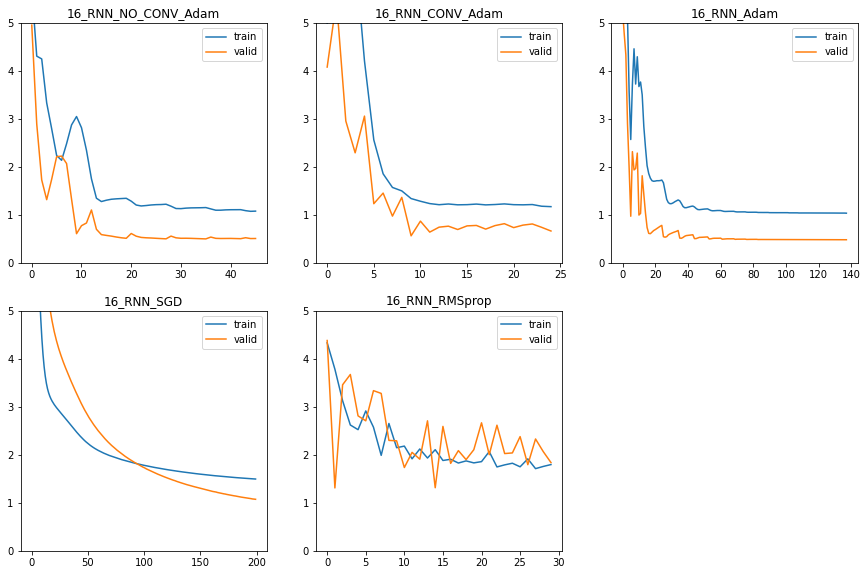

```python
visualize.plot_results(result, ymax = 5, subset="16",grid = True, measure = 'smae')
```

Opmerkelijk dat de modellen eigenlijk allemaal beter presteren op de validatie set dan op de training set. Ik heb hier geen goede verklaring voor. Mogelijk heeft dit te maken met de volatiliteit in de markt. Doordat deze de afgelopen periode lager lag dan voorheen zijn er minder uitschieters waardoor het model het makkelijker heeft op meer recente data.

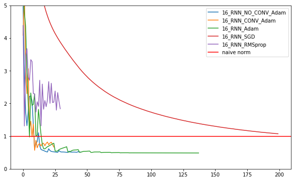

```python
plt.figsize=(8,12)
visualize.naive(result, ylim=5.0, subset="16")
```

In deze fase gaan we de modellen uitbreiden. Er wordt nu gebruik gemaakt van GRU cellen in plaats van gewone RNN cellen om te zorgen dat het model beter in staat is te leren op basis van eventuele patronen uit het verleden.

```python
reduce_lr = ReduceLROnPlateau(monitor='val_loss', factor=0.5,
                              patience=5, min_lr=1e-5)

config = {
    "window"            : window_size,
    "filters"           : 4,
    "kernel"            : 4,
    'activation'        : None,
    'type'              : 'GRU',
    "units"             : 128,
    "hidden"            : 4,
    "horizon"           : horizon,
}

for key in tqdm(["Adam", "SGD", "RMSprop"]):
    early_stop = EarlyStopping(patience=15, restore_best_weights=True)

    name = f"GRU_{key}"
    logdir = Path("logs") / name
    tb = TensorBoard(logdir, histogram_freq=1)

    opt = tf.keras.optimizers.get(key)
    opt.momentum = 0.9
    opt.learning_rate = 0.01

    model = RnnModel(name,config)
    model.compile(loss="mse",
          optimizer=opt,
          metrics=["mae", "mape", smae])

    result[name] = model.fit(train_set,epochs=200,callbacks=[tb, early_stop, reduce_lr],
                            validation_data=valid_set, verbose=0)
    models[name] = model
    print('opt:', key, model.evaluate(valid_set))
```

```
opt: Adam [0.00042648077942430973, 0.01358228549361229, 1.6130728721618652, 0.4976389706134796]
```

```
opt: SGD [0.0007506916881538928, 0.02033139206469059, 2.3792941570281982, 0.7449183464050293]
```

```
opt: RMSprop [0.001377344480715692, 0.03055889718234539, 3.642723321914673, 1.1196420192718506]
```

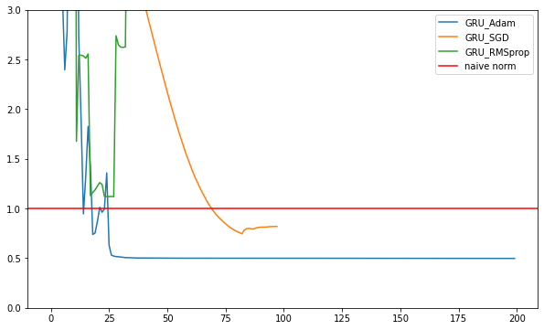

```python
plt.figsize=(8,12)
visualize.naive(result, ylim=3.0, subset="GRU")
```

Het lijkt alsof we een soort plateau bereikt hebben. Modellen komen niet dieper dan ongeveer 0.5 SMAE op de validatieset. Meer complexiteit toevoegen lijkt alleen op het signaal geen waarde te hebben.

```python
# Hypertune

from ray import tune
config = {
    "datadir" : Path("data").absolute(),
    "grace_period" : 3,
    "local_dir" : "logs",
    "epochs" : 20,
    "samples" : 25,
    "window" : tune.qrandint(4, 32, 4),
    "filters" : tune.randint(0, 16),
    "kernel" : tune.qrandint(2, 16, 2),
    "activation" : tune.choice(["relu", None]),
    "type" : tune.choice(["GRU", "LSTM"]),
    "optimizer" : tune.choice(["Adam", "RMSprop"]),
    "hidden" : tune.randint(1, 4),
    "units" : tune.qrandint(16, 256, 16),
    "horizon" : 10,
    "batch_size": 32,
    "shuffle_buffer": 4
}
```

```python
analysis = hyper.hypertune( df_train, df_test, config)
```

== Status ==  
Current time: 2022-02-09 11:36:24 (running for 00:09:40.41)  
Memory usage on this node: 4.2/12.7 GiB  
Using AsyncHyperBand: num_stopped=21 Bracket: Iter 192.000: None | Iter 48.000: None | Iter 12.000: -0.0010469506960362196 | Iter 3.000: -0.0019992664456367493  
Resources requested: 0/2 CPUs, 0/1 GPUs, 0.0/5.74 GiB heap, 0.0/2.87 GiB objects (0.0/1.0 accelerator_type:K80)  
Current best trial: 2591d_00006 with val_loss=0.0006922861211933196 and parameters={'datadir': PosixPath('/content/BondTrading/data'), 'grace_period': 3, 'local_dir': 'logs', 'epochs': 20, 'samples': 25, 'window': 4, 'filters': 15, 'kernel': 8, 'activation': None, 'type': 'GRU', 'optimizer': 'RMSprop', 'hidden': 1, 'units': 224, 'horizon': 10, 'batch_size': 32, 'shuffle_buffer': 4, 'features': 1, 'dropout': 0, 'loss': 'mse', 'loss_alpha': 0}  
Result logdir: /content/BondTrading/logs/hypertune  
Number of trials: 25/25 (25 TERMINATED)

| Trial name | status | loc | activation | filters | hidden | kernel | optimizer | type | units | window | iter | total time (s) | val_loss | val_mae |
| --- | --- | --- | --- | --- | --- | --- | --- | --- | --- | --- | --- | --- | --- | --- |
| wrapper_2591d_00000 | TERMINATED | 172.28.0.2:14631 |  | 10 | 2 | 14 | Adam | LSTM | 32 | 24 | 20 | 33.1268 | 0.00117123 | 0.0267921 |
| wrapper_2591d_00001 | TERMINATED | 172.28.0.2:14632 |  | 13 | 2 | 8 | RMSprop | LSTM | 160 | 12 | 3 | 13.3391 | 0.0250966 | 0.154265 |
| wrapper_2591d_00002 | TERMINATED | 172.28.0.2:15036 |  | 11 | 2 | 4 | Adam | GRU | 224 | 8 | 12 | 23.0157 | 0.00153029 | 0.0331262 |
| wrapper_2591d_00003 | TERMINATED | 172.28.0.2:15234 |  | 5 | 3 | 4 | Adam | GRU | 48 | 8 | 3 | 14.8026 | 0.00505825 | 0.0667292 |
| wrapper_2591d_00004 | TERMINATED | 172.28.0.2:15322 |  | 8 | 1 | 8 | Adam | LSTM | 176 | 24 | 3 | 10.8124 | 0.00261546 | 0.0416003 |
| wrapper_2591d_00005 | TERMINATED | 172.28.0.2:15408 |  | 1 | 2 | 12 | Adam | LSTM | 128 | 20 | 3 | 13.8528 | 0.00881844 | 0.0895407 |
| wrapper_2591d_00006 | TERMINATED | 172.28.0.2:15496 |  | 15 | 1 | 8 | RMSprop | GRU | 224 | 4 | 20 | 23.7778 | 0.000692286 | 0.0182469 |
| wrapper_2591d_00007 | TERMINATED | 172.28.0.2:15790 | relu | 1 | 3 | 8 | RMSprop | GRU | 64 | 16 | 3 | 16.4772 | 0.00707187 | 0.0758874 |
| wrapper_2591d_00008 | TERMINATED | 172.28.0.2:15878 |  | 6 | 3 | 2 | RMSprop | GRU | 32 | 16 | 3 | 14.7509 | 0.00419801 | 0.0584952 |
| wrapper_2591d_00009 | TERMINATED | 172.28.0.2:15966 |  | 0 | 1 | 4 | RMSprop | LSTM | 96 | 8 | 20 | 24.6851 | 0.000864516 | 0.0218203 |
| wrapper_2591d_00010 | TERMINATED | 172.28.0.2:16257 | relu | 9 | 3 | 4 | RMSprop | LSTM | 160 | 28 | 3 | 17.35 | 0.0155961 | 0.117666 |
| wrapper_2591d_00011 | TERMINATED | 172.28.0.2:16347 |  | 6 | 3 | 12 | Adam | GRU | 32 | 24 | 3 | 15.2606 | 0.00566014 | 0.0711056 |
| wrapper_2591d_00012 | TERMINATED | 172.28.0.2:16435 |  | 10 | 3 | 4 | RMSprop | LSTM | 160 | 32 | 3 | 18.446 | 0.00278673 | 0.0421938 |
| wrapper_2591d_00013 | TERMINATED | 172.28.0.2:16523 |  | 3 | 1 | 12 | Adam | GRU | 240 | 8 | 3 | 10.7191 | 0.00861736 | 0.0888732 |
| wrapper_2591d_00014 | TERMINATED | 172.28.0.2:16606 | relu | 9 | 3 | 4 | RMSprop | LSTM | 32 | 28 | 3 | 15.3617 | 0.00288784 | 0.0444812 |
| wrapper_2591d_00015 | TERMINATED | 172.28.0.2:16694 |  | 1 | 2 | 2 | RMSprop | LSTM | 112 | 24 | 3 | 15.0069 | 0.0101564 | 0.0880252 |
| wrapper_2591d_00016 | TERMINATED | 172.28.0.2:16783 |  | 8 | 3 | 6 | Adam | LSTM | 240 | 20 | 12 | 31.8338 | 0.00273843 | 0.0468973 |
| wrapper_2591d_00017 | TERMINATED | 172.28.0.2:16983 |  | 11 | 3 | 12 | RMSprop | LSTM | 112 | 12 | 12 | 26.6046 | 0.00255803 | 0.0450623 |
| wrapper_2591d_00018 | TERMINATED | 172.28.0.2:17181 |  | 10 | 3 | 4 | Adam | GRU | 48 | 12 | 3 | 15.2696 | 0.00472337 | 0.064482 |
| wrapper_2591d_00019 | TERMINATED | 172.28.0.2:17269 |  | 13 | 1 | 4 | RMSprop | GRU | 64 | 24 | 20 | 29.7578 | 0.000755925 | 0.0200823 |
| wrapper_2591d_00020 | TERMINATED | 172.28.0.2:17563 | relu | 15 | 3 | 12 | Adam | LSTM | 48 | 32 | 12 | 30.3288 | 0.00177524 | 0.0351418 |
| wrapper_2591d_00021 | TERMINATED | 172.28.0.2:17763 | relu | 14 | 3 | 4 | Adam | GRU | 176 | 16 | 3 | 16.1641 | 0.00259594 | 0.0408946 |
| wrapper_2591d_00022 | TERMINATED | 172.28.0.2:17851 | relu | 7 | 1 | 12 | RMSprop | LSTM | 48 | 8 | 3 | 10.9741 | 0.00337385 | 0.0534831 |
| wrapper_2591d_00023 | TERMINATED | 172.28.0.2:17937 | relu | 10 | 1 | 4 | Adam | GRU | 96 | 20 | 3 | 13.0453 | 0.0028657 | 0.0490291 |
| wrapper_2591d_00024 | TERMINATED | 172.28.0.2:18025 |  | 8 | 3 | 6 | RMSprop | LSTM | 128 | 20 | 3 | 15.7549 | 0.00275042 | 0.0416318 |

```
2022-02-09 11:36:24,645	INFO tune.py:636 -- Total run time: 586.21 seconds (580.39 seconds for the tuning loop).
```

```python
config = analysis.get_best_config()
config
```

```
{'activation': None,
 'batch_size': 32,
 'datadir': PosixPath('/content/BondTrading/data'),
 'epochs': 20,
 'filters': 15,
 'grace_period': 3,
 'hidden': 1,
 'horizon': 10,
 'kernel': 8,
 'local_dir': 'logs',
 'optimizer': 'RMSprop',
 'samples': 25,
 'shuffle_buffer': 4,
 'type': 'GRU',
 'units': 224,
 'window': 4}
```

```python
window_size = config["window"]
horizon = config["horizon"]
name = "hypertuned"

train_set = window.windowed_dataset(
    df_train, window_size, batch_size=256, shuffle_buffer=2, horizon=horizon
)
valid_set = window.windowed_dataset(
    df_train, window_size, batch_size=256, shuffle_buffer=2, horizon=horizon
)
reduce_lr = ReduceLROnPlateau(
    monitor="val_loss", factor=0.1, patience=5, min_lr=1e-5
)
opt = tf.keras.optimizers.get(config["optimizer"])
opt.momentum = 0.9
opt.learning_rate = 0.01
model = RnnModel(name, config)
model.compile(loss="mse", optimizer=opt, metrics=["mae", "mape", smae])
early_stop = EarlyStopping(patience=10, restore_best_weights=True)
result[name] = model.fit(
        train_set,
        epochs=150,
        validation_data=valid_set,
        callbacks=[reduce_lr, early_stop],
    )
models[name] = model
```

```
2022-02-09 11:38:15.502 | INFO     | src.data.window:windowed_dataset:20 - Split windowed dataset window_size = 4 batch_size =  256, shuffle_buffer =  2 ,horizon =  10
2022-02-09 11:38:15.546 | INFO     | src.data.window:windowed_dataset:20 - Split windowed dataset window_size = 4 batch_size =  256, shuffle_buffer =  2 ,horizon =  10
```

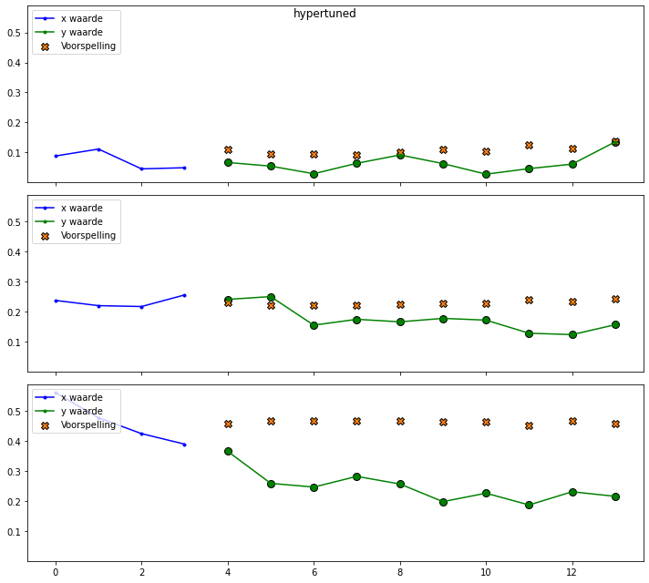

```python
fig = visualize.plot_example(
    valid_set,
    window_size = window_size,
    horizon = 10,
    examples = 3,
    model = model,
    figurepath = Path("reports/figures/")
)
```

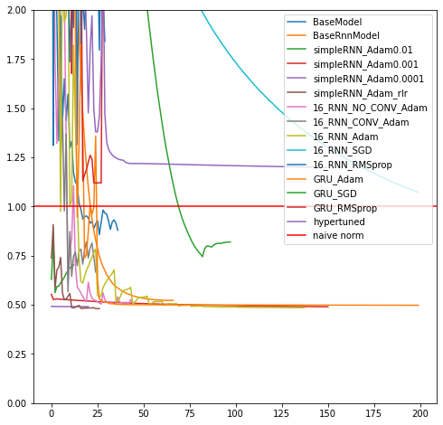

```python
plt.figure(figsize=(8,8))
visualize.naive(result, ylim=2, subset = '')
```

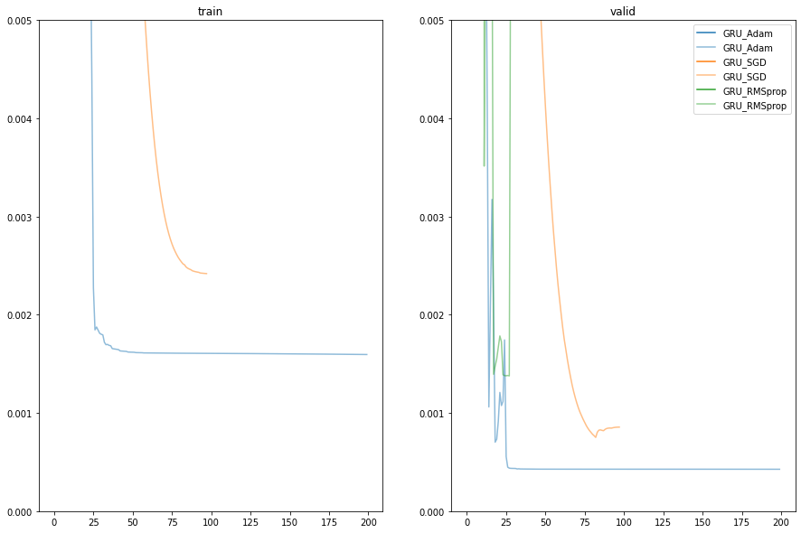

```python
visualize.plot_results(result, ymax = 0.005, subset = 'GRU')
```

Het hypertuned model scored slechter dan de eenvoudige modellen. Het GRU model met Adam optimizer scoort ongeveer gelijk aan de simpele modellen.

```python
model = models['GRU_Adam']
window_size = 32
```

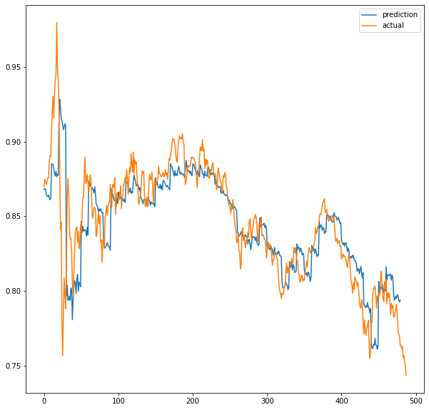

```python
pred = evaluate.generate_prediction(model, df_test, window = window_size, horizon = horizon)
```

Dit plaatje laat ook wel zien dat dit model nog niet een erg goede voorspeller is van de bond prijzen. Maar het moeilijk om precies aan te geven hoe goed of hoe slecht het model nu presteert en of dit dus zinvol zou kunnen zijn voor algotrading. De MSE en MAPE geven hier niet echt een waarde waar de business een gevoel mee heeft. Met name de MAPE waarden zijn extreem hoog. mogelijk gaat hier iets mis - maar dat heb ik niet precies kunnen achterhalen. Een 1-dags voorspelling geeft eigenlijk altijd een goede aansluiting tussen beide curves.

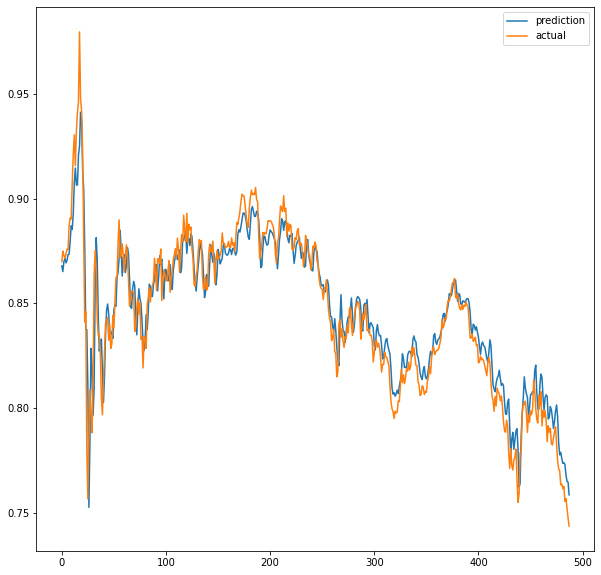

```python
pred = evaluate.generate_prediction(model, df_test, window = window_size, horizon = 1)
```